# Next Word Predict Capstone Project

Geanderson Esteves dos Santos  
11 August, 2020

Data Science Specialization  
Capstone Project

# **Objective**

This presentation highlights the Next Word Predict app concerning an introduction to the application UI and aspects of the text prediction algorithm.

The source code files can be found on GitHub:

- https://github.com/gesteves91/milestone-capstone

I recommend checking regularly the source code as I will continually update the app.

# **Shiny Application**

Next Word Predict is an app that uses a text prediction algorithm to predict the next word based on text input by the user.

The application suggests the next word in a sentence using an n-gram algorithm. An n-gram is a contiguous sequence of *n* words from a given sequence of text.

The text handled to build the predictive text model came from a large corpus of blogs, news, and Twitter data. N-grams were extracted from the corpus and then used to formulate the predictive text model.

Various systems were explored to improve speed and accuracy using natural language processing and text mining techniques.

# **The Predictive Text Model**

The predictive model was built under a sample of 800,000 lines extracted from the large corpus of blogs, news and twitter data.

The sample data is tokenized and cleaned using the **tm** package and several regular expressions using the **gsub** function. As part of the cleaning process the data was converted to lowercase, removed all non-ASCII characters, URLs, email addresses, Twitter handles, hashtags, ordinal numbers, profane words, punctuation, and whitespace. The data was then split into tokens (n-grams).

As the text is entered by the user, the algorithm iterates from the longest n-gram (4-gram) to the shortest (2-gram) to detect a match. The predicted next word is considered using the longest, most frequent matching n-gram. The algorithm makes use of a simple back-off strategy.

# **Application User Interface**

The predicted word is shown when the app detects that you have finished typing one or more words. When entering text, wait a few seconds for the output. Use the slider tool to select up to three next-word predictions. The top prediction is shown first. And then, the second and third likely next words. Click the image below for a larger view of the user interface.

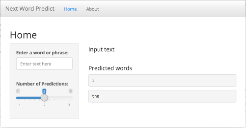